# Matrix Notation for statistics

Matrix and vector notation comes form the branch of mathematics called Linear algebra. Matrices and vectors are used in essentially all statistical disciplines, and a key to understanding theoretical and empirical properties of our statistical models. We'll define a vector, matrix, and how they interact in the context of statistics.

Our end goal will be to understand how linear regression can be represented using vectors as matrices, understanding this equation

$$ Y \sim \mathcal{N}(X\beta,\sigma^{2}) $$

First, we'll define vectors and understand how they can represent data and points in n-dimensional space. Next we'll define Matrices and different ways of conceptualizing them. After defining vectors and matrices separatley, we'll lear about they can interact: vector times vector, vector time matrix, and matrix times matrix. Finally, we'll frame linear regression in terms of matrices and vectors.

## Vector

A vector is an $n$-dimensional collection of real numbers. Vectors are represented as a stack of these $n$ numbers, surrounded by brackets. For example,

\begin{align*} y = \left[ \begin{array}{c} y_{1}\\ y_{2}\\ y_{3}\\ \vdots\\ y_{n}\\ \end{array} \right] \end{align*}

is a vector with $n$ elements.

A specific example of a vector with values is \begin{align*} h = \left[ \begin{array}{c} 34\\ 22.2\\ 83/2\\ \end{array} \right] \end{align*} $h$ is a vector of length $3$. The first element is 34, second 22.2, and third 83/2.

Vectors generalize the number line. A $n$-dimensional vector represents a single point in a $n$-dimensional space of real numbers. Real numbers can be thought of as $1$-dimensional vectors. For example the expression $r=45.456$ could be represented as \begin{align*} r = \left[ \begin{array}{c} 45.456 \end{array} \right], \end{align*} a 1-dimensional vector with a single value 45.456.

Vectors can help us gain intuition about how statistical model are fit. For example, scatterplots can be thought of as a collection of 2-dimensional vectors

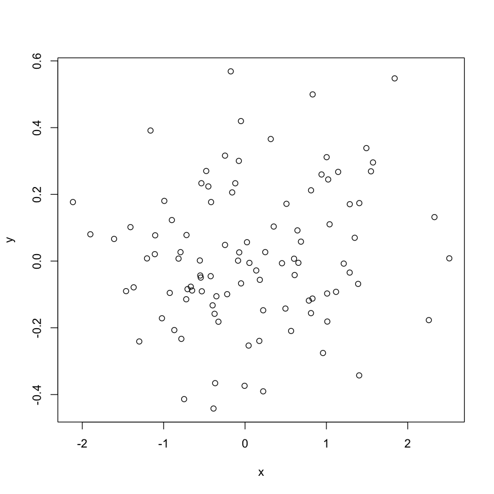

```r
x <- rnorm(100,0,1)
y <- rnorm(100,0,0.2)
plot(x,y)
```

Each point on the scatter plot above can be represented as a "tuple" $(x,y)$ or viewed as a single 2-dimensional vector.

## Matrix

A matrix is a collection of vectors, and have two dimensions written with square brackets, for example \begin{align*} M = \left[ \begin{array}{cc} 34 & 55\\ 22.2 & 0.9\\ 83/2 & 76.3\\ \end{array} \right] \end{align*} We'll use capital letters to denote matrices, like this

\begin{align*} X = \left[ \begin{array}{cc} 4 & 55\\ 1/3 & 1.9\\ 0.88 & 99.3\\ \end{array} \right] \end{align*}

Matrices can represent different concepts in statistics. They can $P$ variables collected from a set of $N$ observations. For example, height, weight, BMI, and CKMB enzyme levels for patients atrisk for a myocardial infarction (heart attack).

In this example, each row would represent a patient, and the columns would represent height (inches), weight (kg), and CKMB levels (IU/L). Our matrix can be constructed like

\begin{align*} D = \left[ \begin{array}{cccc} 60 & 77 & 8\\ 54 & 50 & 18\\ 63 & 90 & 4\\ \end{array} \right] \end{align*}

## vector times vector (the inner product)

Consider two vectors $a$ and $b$. Each is length $4$, representing a single point in a 4-dimensional Real space. \begin{align*} a = \left[ \begin{array}{c} 1\\ 2\\ 3\\ 4\\ \end{array} \right] ; b = \left[ \begin{array}{c} 5\\ 6\\ 7\\ 8\\ \end{array} \right] \end{align*}

Then we define the **inner product** of these two vectors as \begin{align*} a'b &= \sum_{i=1}^{4} a_{i} \times b_{i} \\ &= 1 \times 5 + 2 \times 6 + 3 \times 7 + 4 \times 8\\ &= 70 \end{align*} where the $'$ symbol stand for transpose.

The transpose "flips" the rows and columns of a vector or matrix. If \begin{align*} a = \left[ \begin{array}{c} 1\\ 2\\ 3\\ 4\\ \end{array} \right] \end{align*} a vector with $4$ rows and $1$ column then $a'$ is a vector with $1$ row and $4$ columns \begin{align*} a = \left[ \begin{array}{cccc} 1 & 2 & 3 & 4 \end{array} \right] \end{align*}

## matrix times matrix

Consider two matrices $A$ and $B$. $A$ has $2$ rows and $3$ columns. $B$ has $3$ rows and $5$ columns. \begin{align*} A = \left[ \begin{array}{ccc} 1 & 2 & 3\\ 4 & 5 & 6\\ \end{array} \right] \end{align*}

\begin{align*} B = \left[ \begin{array}{ccccc} 7 & 8 & 9 & 10 & 11\\ 12 & 13 & 14 & 15 & 16\\ 17 & 18 & 19 & 20 & 21\\ \end{array} \right] \end{align*}

Then we define the $(i,j)$ element of the product of matrix $A$ and $B$ as \begin{align} A B (i,j) = \sum_{r=1}^{3} a(i,r) b(r,j) \end{align}

Another way to look at this matrix multiplication product is by using an inner product. Redefine the matrix A in terms of two "row" vectors and B in terms of 5 "column" vectors.

\begin{align*} A &= \left[ \begin{array}{ccc} 1 & 2 & 3\\ 4 & 5 & 6\\ \end{array} \right]\\ % &= \left[ \begin{array}{c} a_{1}\\ a_{2} \end{array} \right] \end{align*}

where \begin{align*} a_{1} &= \left[ \begin{array}{c} 1\\ 2\\ 3 \end{array} \right]\\ % a_{2}&= \left[ \begin{array}{c} 4\\ 5\\ 6 \end{array} \right] \end{align*}

and

\begin{align*} B = \left[ \begin{array}{ccccc} b_{1} & b_{2} & b_{3} & b_{4} & b_{5} \end{array} \right] \end{align*}

where \begin{align*} b_{1} &= \left[ \begin{array}{c} 7\\ 12\\ 17 \end{array} \right] \end{align*} and so on. Then we can redefine the $(i,j)$ element of $A$ times $B$ as an inner product \begin{align} A B (i,j) &= \sum_{r=1}^{3} a(i,r) b(r,j)\\ &= a_{i}'b_{j} \end{align}

## matrix times vector

Consider a vector $\beta$ and matrix $X$. The product is a vector, where the ($i^{\text{th}}$) element equals

\begin{align} X \beta (i) = \sum_{j} X(i,j) \beta_{j} \end{align}

or the inner product \begin{align} X \beta (i) = x'_{i} \beta \end{align}

where $x_{i}$ is the $i^{\text{th}}$ row vector of the matrix $X$

## Matrix notation for Simple Linear regression

The above terminology and methods manipulating vectors and matrices can allow us to express linear regression as an operation on matrices and vectors.

### model form (system of equations)

Simple linear regression relates a variable $x$ to a variable $y$ by a simple formula \begin{align} y &= \beta_{0} + \beta_{1} x + \epsilon\\ \epsilon & \sim N(0,\sigma^{2}) \end{align} A simple linear regression equation states any value $y$ can be probabilistically predicted or explained by knowing the corresponding value $x$, $\beta_{0}$, $\beta_{1}$, and the variance $\sigma^{2}$ . Given a list of $n$ values for $x$, a value for $\beta_{0}$ and a value for $\beta_{1}$, we can rewrite the above equation in matrix notation. $$ y = X\beta + \epsilon $$ where $y$ is a vector of length $n$, $$ y = \left[ \begin{array}{c} y_{1}\\ y_{2}\\ \vdots\\ y_{n} \end{array} \right] $$

$\beta$ is a vector containing $\beta_{0}$ and $\beta_{1}$,

$$ \beta = \left[ \begin{array}{c} \beta_{0}\\ \beta_{1}\\ \end{array} \right], $$

and $$ X = \left[ \begin{array}{cc} 1 & x_{1}\\ 1 & x_{2}\\ 1 & x_{3}\\ \vdots & \vdots\\ 1 & x_{n} \end{array} \right] $$ is a matrix; the first colummn all ones and the second column the values of $x$. Epsilon is a vector of length $n$ $$ \epsilon = \left[ \begin{array}{c} \epsilon_{1}\\ \epsilon_{2}\\ \vdots\\ \epsilon_{n} \end{array} \right] $$

every value following a Normal distribution with variance $\sigma^{2}$.

Written this way, we can define a structure or functional form for all values of $y$ and $x$ at once. The functional form does not look that different from our original $y=\beta_{0} + \beta_{1}x + \epsilon$, and is even more compact.

### probability form

The equation \begin{align} y &= X\beta + \epsilon\\ \epsilon & \sim N(0,\sigma^{2}) \end{align} explains the probabilstic, and linear relationship, between $x$ and $y$. But I believe we can do better. Tha above equation can confuse the non-statistically inclined. Oftne, they may focus on the linear relationship, forgetting the probabilistic component because of how it is writtne. The $\epsilon$ appears like an after thought.

To more clearly communicate the fact that the relationship between $y$ and $x$ is probabilistic, we can write $$ y \sim N(X\beta,\sigma^{2}), $$ read y is Normally distributed with mean $X\beta$ and variance $\sigma^2$. This expression, called the probabilstic form, more clearly communicates that the relationship between $y$ and $x$ is not deterministic, and allowed to fluctuate around a mean that depends on $x$ and on $\beta$.